# Reflections. Tales from the Genome. Lessons 7-8

## Useful links

http://learn.genetics.utah.edu/

http://www.bbc.co.uk/bitesize/intermediate2/biology/environmental_and_genetics/phenotype_and_genotype/revision/2/

http://biotechlearn.org.nz/themes/dna_lab/dna_extraction

https://www.khanacademy.org/test-prep/mcat/biomolecules/dna-technology/e/dna-technology-questions

http://www.appliedbiosystems.com/absite/us/en/home/applications-technologies/dna-sequencing-fragment-analysis/overview-of-dna-sequencing/data-analysis.html

https://www.familytreedna.com/understanding-dna.aspx

https://ghr.nlm.nih.gov/primer/mutationsanddisorders/possiblemutations

https://en.wikibooks.org/wiki/Next_Generation_Sequencing_(NGS)

http://www.snpedia.com/index.php/SNPedia

http://www.ncbi.nlm.nih.gov/SNP/

http://isogg.org/wiki/Identical_by_descent

http://www.omim.org/

```python
import webbrowser
from IPython.display import Image
```

## Glossary

Activator: transcription factors that bind to an enhancer and increase transcriptional activity

Adenine (A): a type of nitrogenous base that is typically used in both DNA and RNA (A basepairs with U or T)

Allele: Specific variant of a genetic sequence for which more than one variation exists, sometimes associated with a unique phenotype

Allele Frequency: the frequency of an allele is equal to the number of that allele divided by the total number of alleles in a given population

Amino Acid: the basic building blocks of proteins, combined by ribosomes during the process of translation; there are 20 different amino acids

Aneuploidy: a chromosomal aberration in which certain chromosomes are present in extra copies or are deficient in number

Autosome: a nuclear chromosome that is not a sex chromosome (X or Y)

Basepair: the phenomenon of nitrogenous bases in nucleic acid pairing with one another in double-stranded DNA or RNA, following the rules A:T, G:C in DNA and A:U, G:C in RNA

Behavioral Trait: any trait that concerns an organism's action or interaction with or within an environment, for example: aggressiveness

Bioethicist: someone who focuses on ethical issues relating to biological topics

Blending Inheritance: the idea that a particular trait in an offspring is a mix of the parents’ traits

Bottleneck: genetic drift resulting from the reduction of a population, typically by a natural disaster, such that the surviving population is no longer genetically representative of the original population

Chromosome: a super-coiled structure of organized DNA wrapped around histones; contains a single molecule of DNA

Coding DNA: sometimes referred to as "protein-coding DNA"; refers to any sequence in the genome that specifies amino acids and translation signals (initiation and termination codons)

Codon: a three-nucleotide sequence of mRNA that specifies a particular amino acid or termination signal

Combinatorial Regulation: the idea that transcription of most genes is controlled by more than one activator or repressor to achieve a particular level of activity

Computational Biologist: someone who applies their knowledge of computer science or computer coding to biological problems

Concordance: the presence of the same trait in both members of a pair of twins or set of individuals

Consensus Sequence: a single sequence that represents the most prevalent individual unit at each position, derived by comparing variants of the sequence from different sources

Correlation: refers to an observable relationship between any paired values

Cytochrome P450: a large and diverse group of enzymes that catalyze the oxidation (metabolism) of organic substances (drugs)

Cytoplasm: the interior of a cell, excluding the nucleus

Cytosine (C): a type of nitrogenous base that is typically used in both DNA and RNA (C basepairs with G)

Deoxynucleotides: the building blocks of DNA; there are four different bases used in deoxynucleotides: Adenine (A), Thymine (T), Guanine (G), and Cytosine (C)

Direct Selection: (see natural selection)

Director Of Clinical Operations: someone who designs and manages clinical trials

Dizygotic Twins: twins that came from two different fertilized eggs or zygotes; fraternal twins

DNA: deoxyribonucleic acid; the hereditary material of almost all cells that makes up their genomes

DNA Amplification: the in vitro replication of a DNA sequence to make many more copies

DNA Extraction: the isolation of DNA from a biological sample

DNA Sequence: a string of DNA letters (bases) in consecutive order

Dominant Trait: can mask the presence of a recessive allele or trait

Double Helix: the structure of DNA, referring to its two adjacent strands wound into a spiral shape and held together through basepairing

Duplicated Chromosome: the stereotypical structure in the shape of an "X" for a nuclear chromosome that appears only before cell division

Duplication: a replication error that doubles a large segment of DNA

Efficacy: a drug's ability to produce a therapeutic effect

Egg: female reproductive cell

Enhancer: a DNA sequence that binds certain transcription factors, activators, that can stimulate transcription of nearby genes

Enzyme: a class of proteins that enable chemical reactions without being consumed by the reaction

Exon: a sequence from a gene that is transcribed and remains in the mRNA after splicing and includes codes for amino acids

Founder Effect: a cause of genetic drift attributable to colonization by a limited number of individuals from a parent population

Frameshift: any mutation that results in changing the reading frame of translation

Gain-Of-Function Mutation: changes the gene product such that it gains a new and/or abnormal function

Gamete: sperm or egg cells; produce as a result of meiosis from germ cells

Gene: a discrete unit of hereditary information consisting of a specific deoxynucleotide sequence in DNA

Gene Expression: the process by which information from a gene is used in the synthesis of a functional gene product

Genetic Counselor: someone who explains and discusses personal genetic information with individuals and families

Genetic Genealogist: someone who uses genetic information to determine and catalog family relationships and uncover ancestry

Genome: the complete complement of an organism's genetic material

Genome Wide Association Study (GWAS): GWAS seek to correlate, in populations, the association of specific alleles with the trait or disorder being studied

Genotype: the genetic makeup of an organism, specifically the composition of alleles

Germ Cell: the type of the cell in the body that makes gametes; this is the only cell type where mutations affect the next generation of an organism

Guanine (G): a type of nitrogenous base that is typically used in both DNA and RNA (G basepairs with C)

Hidden Trait: any trait that is not apparent through outward observation

Histone: a protein that is used to organize and fold DNA like a string on a spool

Heterozygous: having two different alleles for a given gene

Heterozygote Advantage: describes the case in which the heterozygous genotype has a higher relative fitness than either the homozygous dominant or homozygous recessive genotype

Heritability: the proportion, between 0 and 1, of observable differences in variation of a trait between individuals within a population that is due to genetic differences

Homozygous: having two identical alleles for a given gene

Human Geneticist: someone who studies human genetics and inheritance

Hybridization: the process of basepairing that can occur between any types of nucleic acids (DNA:DNA, DNA:RNA, or RNA:RNA)

Identity By Descent (IBD): genetic sequence shared through ancestry

Identity By Descent (IBD): genetic sequence shared through ancestry

Identity By State (IBS): genetic sequence that is identical between two individuals

Inheritance: the passing down of traits from one generation to the next, at the level of the cell or the organism

Innate Trait: any trait that is in-born, for example: your pancreas secreting enzymes that break down the food in your gut

Intron: a sequence from a gene that is transcribed but cut out of the mRNA by splicing and typically does not code for any amino acids

Learned Trait: any trait that is not in-born and instead acquired through environmental (typically cognitive) influence, for example: belief in a particular religion

Loss-Of-Function Mutation: results in the gene product having less or no function

Meiosis: a two-stage type of cell division in germ cells that results in gametes with half the chromosome number of the original cell

Mitochondrial DNA: a circular DNA molecule that can only be found in the mitochondria of all cells in the body and is inherited only from the mother

Mitosis: the normal chromosome doubling and division that all somatic (body) cells do to maintain the same number of chromosomes at the end of each division

Missense/Non-Synonymous Mutation: a mutation that changes an amino acid

Monogenic Trait: traits that are significantly influenced by a single gene

Monozygotic Twins: twins that came from the same fertilized egg or zygote; identical twins

Multifactorial Trait: a trait that is controlled by many genes and is also influenced by the environment

Mutation: a change in the genetic sequence

Natural Selection: the process by which traits become either more or less common in a population because of pressures directly affecting the reproductive fitness of individuals carrying particular alleles; also considered "direct selection" due to pressures that directly affect the fitness of particular alleles

Non-coding DNA: any sequence that does not specify amino acids and translation signals (initiation and termination codons)

Non-Duplicated Chromosome: a non-"X"-shaped nuclear chromosome;

Nonsense Mutation: a mutation that changes an amino acid codon to a STOP codon

Nuclear Genome: the complete set of 23 pairs of chromosomes that reside within the nucleus of the cell

Nucleotide: building block of DNA and/or RNA consisting of a base, a ribose or deoxyribose sugar and a phosphate group; there are five different bases used in nucleotides: Adenine (A), Thymine (T) in DNA or Uracil (U) in RNA, Guanine (G), and Cytosine (C)

Nucleus: a separate, membrane-bound compartment of eukaryotic cells that houses the DNA and separates it from the rest of the cell; this is where transcription occurs

Particulate Inheritance: the idea that characteristics can be passed down from generation to generation through discrete particles, i.e. genes

Pedigree: organized way of illustrating (drawing) family relations and traits

Penetrance: the degree to which a particular allele causes a trait

Personal Genome: the entirety of your own individual DNA

Pharmacodynamics: the target effects of a drug; what a drug does to the body

Pharmacogenetics/Pharmacogenomics: the study of how different drugs interact with the body in different ways based on genetic variation

Pharmacokinetics: how a drug is metabolized; what the body does to a drug

Pharmacology: the study of drugs and their origins, as well as how they interact with the body of a living organism

PharmGKB: Pharmacogenomics Knowledge Base is an interactive tool for researchers to investigate how genetic variation affects drug response, both with regards to pharmacodynamics and pharmacokinetics

Phenotype: the physical makeup, or appearance, of an organism or individual trait

Physical Trait: any trait that concerns our material makeup

Polygenic Trait: a trait that is the result of multiple gene interactions with very little environmental impact

Population: a group of individuals of one species that live in a particularly defined area

Promoter: a region of DNA at which transcription of a particular gene is initiated

Protein: a large chain or combination of multiple chains of amino acids

Promoter: a region of DNA at which transcription of a particular gene is initiated

Qualitative Trait: a trait that is described by either its presence or absence

Quantitative Trait: a trait that varies continuously over a range of measurements and displays a normal distribution (bell curve)

Random Selection: the process by which traits become either more or less common in a population due to random chance, not because of pressures directly affecting the reproductive fitness of particular alleles; it is random because the pressures do not directly affect the fitness of particular alleles

Recessive Trait: masked by the presence of a dominant allele or trait

Recombination: a special process during meiosis that can swap pieces of your maternal and paternal chromosome copies

Relative Risk: an individual's risk based on family or genetic background compared to the general population

Repressor: transcription factors that bind to a silencer and inhibit transcriptional activity

Ribosome: a molecular machine that translates, or reads, the genetic code within the mRNA sequence and synthesizes a corresponding chain of amino acids

RNA and mRNA: ribonucleic acid; A type of nucleic acid, usually single-stranded, consisting of nucleotides with the nitrogenous bases of A, C, G, and U

RSID: reference SNV identification

Sex Chromosome: a nuclear chromosome that distinguishes the sexes: XY - male, XX - female, and can affect sex-specific traits

Silencer: a DNA sequence capable of binding transcription regulation factors, called repressors, and inhibit transcriptional activity

Silent/Synonymous Mutation: a mutation that does not change the amino acid sequence

Single Nucleotide Variation (SNV): single base change in DNA; SNVs (also known as single nucleotide polymorphisms, or SNPs) are one of the smallest kinds of mutations and are responsible for a large number of differences among humans

SNV Genotyping: determining the base at any given position in a genome, not through total genome sequencing

Somatic Cell: any cell of the body that is not a germ cell (not directly responsible for carrying the information passed on to the next generation)

Splicing: the process of removing introns and combining exons in a mRNA sequence after transcription

TATA-Box: the TATAAA sequence that can be found in the promoter of many genes and is essential to initiate transcription

Thymine (T): a type of nitrogenous base that is typically used in DNA (T basepairs with A)

Toxicity: the degree to which a drug causes negative effects

Trait: any distinguishing feature of an individual

Transcription: the step of gene expression in which a particular segment of DNA is copied into RNA

Transcription Factor: any protein that joins the transcription process by binding to DNA or to other proteins that bind DNA to regulate transcription

Translation: the process by which ribosomes read the mRNA sequence and connect the amino acids in the order specified by the sequence

Translocation: rearrangement of a large sequence of genetic information, typically transferring from one chromosome to another through DNA breakage and resealing

Uracil (U): a type of nitrogenous base that is typically used in RNA (U basepairs with A)

Variant: version of a genetic sequence or gene for which more than one version exist

Variation: diversity among members of a population

Visible Trait: any trait that is apparent through outward observation

X Chromosome: one of two mammalian sex chromosomes that can be found in both males (XY) and females (XX)

Y Chromosome: the mammalian sex-determining chromosome that can only be found in males (XY) and is passed from father to son

## Lesson 7

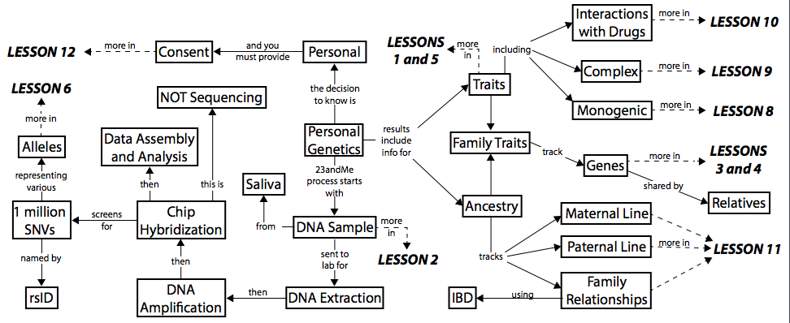

```python
Image(filename='cm07.jpg')
```

### Concept map

http://content.udacity-data.com/course/bio110/Lesson_7_Concept_Map.pdf

DNA Extraction is the removal of deoxyribonucleic acid (DNA) from the cells or viruses in which it normally resides. What does DNA extraction involve? Step 1. Breaking cells open to release the DNA The cells in a sample are separated from each other, often by a physical means such as grinding or vortexing, and put into a solution containing salt. The positively charged sodium ions in the salt help protect the negatively charged phosphate groups that run along the backbone of the DNA.

A detergent is then added. The detergent breaks down the lipids in the cell membrane and nuclei. DNA is released as these membranes are disrupted.

Step 2. Separating DNA from proteins and other cellular debris To get a clean sample of DNA, it’s necessary to remove as much of the cellular debris as possible. This can be done by a variety of methods. Often a protease ( protein enzyme) is added to degrade DNA-associated proteins and other cellular proteins. Alternatively, some of the cellular debris can be removed by filtering the sample.

Step 3. Precipitating the DNA with an alcohol Finally, ice-cold alcohol (either ethanol or isopropanol) is carefully added to the DNA sample. DNA is soluble in water but insoluble in the presence of salt and alcohol. By gently stirring the alcohol layer with a sterile pipette, a precipitate becomes visible and can be spooled out. If there is lots of DNA, you may see a stringy, white precipitate.

Step 4. Cleaning the DNA The DNA sample can now be further purified (cleaned). It is then resuspended in a slightly alkaline buffer and ready to use.

Step 5. Confirming the presence and quality of the DNA For further lab work, it is important to know the concentration and quality of the DNA.

Optical density readings taken by a spectrophotometer can be used to determine the concentration and purity of DNA in a sample. Alternatively, gel electrophoresis can be used to show the presence of DNA in your sample and give an indication of its quality.

Get information sheet: Gel electrophoresis

What can this DNA be used for? Once extracted, DNA can be used for molecular analyses including PCR, cloning, electrophoresis and sequencing.

DNA amplification: The production of multiple copies of a sequence of DNA. Repeated copying of a piece of DNA. Amplification can occur in vivo (in the living individual) or in vitro (literally "in glass", or in a plastic vessel in the laboratory).

###### Introduction to Microarray

Molecular Biology research evolves through the development of the technologies used for carrying them out. It is not possible to research on a large number of genes using traditional methods. DNA Microarray is one such technology which enables the researchers to investigate and address issues which were once thought to be non traceable. One can analyze the expression of many genes in a single reaction quickly and in an efficient manner. DNA Microarray technology has empowered the scientific community to understand the fundamental aspects underlining the growth and development of life as well as to explore the genetic causes of anomalies occurring in the functioning of the human body.

A typical microarray experiment involves the hybridization of an mRNA molecule to the DNA template from which it is originated. Many DNA samples are used to construct an array. The amount of mRNA bound to each site on the array indicates the expression level of the various genes. This number may run in thousands. All the data is collected and a profile is generated for gene expression in the cell.

###### Microarray Technique

An array is an orderly arrangement of samples where matching of known and unknown DNA samples is done based on base pairing rules. An array experiment makes use of common assay systems such as microplates or standard blotting membranes. The sample spot sizes are typically less than 200 microns in diameter usually contain thousands of spots.

Thousands of spotted samples known as probes (with known identity) are immobilized on a solid support (a microscope glass slides or silicon chips or nylon membrane). The spots can be DNA, cDNA, or oligonucleotides. These are used to determine complementary binding of the unknown sequences thus allowing parallel analysis for gene expression and gene discovery. An experiment with a single DNA chip can provide information on thousands of genes simultaneously. An orderly arrangement of the probes on the support is important as the location of each spot on the array is used for the identification of a gene.

###### Types of Microarrays

Depending upon the kind of immobilized sample used construct arrays and the information fetched, the Microarray experiments can be categorized in three ways:

1 Microarray Expression Analysis: In this experimental setup, the cDNA derived from the mRNA of known genes is immobilized. The sample has genes from both the normal as well as the diseased tissues. Spots with more intensity are obtained for diseased tissue gene if the gene is over expressed in the diseased condition. This expression pattern is then compared to the expression pattern of a gene responsible for a disease.

2 Microarray for Mutation Analysis: For this analysis, the researchers use gDNA. The genes might differ from each other by as less as a single nucleotide base.

A single base difference between two sequences is known as Single Nucleotide Polymorphism (SNP) and detecting them is known as SNP detection.

3 Comparative Genomic Hybridization: It is used for the identification in the increase or decrease of the important chromosomal fragments harboring genes involved in a disease.

##### Data Analysis

After electrophoresis, data collection software creates a sample file of the raw data. Using downstream software applications, further data analysis is required to translate the collected color-data images into the corresponding nucleotide bases.

###### Mobility Shift Correction

The mobility file compensates for the change in DNA fragment mobility caused by the dye molecule attached to the DNA fragment and changes the color designation of bases depending on the type of chemistry used to label the DNA.

###### Quality Value (QV)

If the KB basecaller is used for analysis, the software assigns a QV for each base. The QV predicts the probability of a basecall error. For example, a QV of 20 predicts an error rate of 1%. The quality prediction algorithm is calibrated to return QVs that conform to the industry-standard relationship established by the Phred software. If your pipeline involves analysis with Phred software to assign QVs after the data is basecalled, you can simplify your workflow and use the KB basecaller instead. The KB basecaller can perform basecalling and assign QVs. Then, you can generate *phd.1 or* .scf files using the KB basecaller to integrate with your downstream pipeline.

###### Secondary Analysis

These tools allow you to further refine your results. Algorithms in our secondary analysis software products perform a number of functions supporting applications such as mutation detection and genotyping, and produce graphical outputs.

###### What is the direct maternal lineage?

Your direct maternal lineage is the line that follows your mother’s maternal ancestry. With the exception of yourself, if you are male, this line consists entirely of women. It traces your mother, her mother, her mother’s mother, and so forth back to our shared common maternal ancestor. For genealogists, this clear line means that they can trace two or more descendants of a single woman many generations back and compare their mtDNA results with the expectation of a match. For those interested in deeper ancestry, tracing the modern geographic origins of exact matches means that they can discover the origins of their own line.

Note that because mtDNA follows exclusively the direct maternal line, common ancestors between you and your matches on other parts of your tree are coincidental.

###### Y-Chromosome DNA

The Y chromosome is transmitted from father to son. Testing the Y chromosome provides information about the direct male line, meaning the father to his father and so on. The locations tested on the Y chromosome are called markers. Occasionally a mutation occurs at one of the markers in the Y chromosome. Mutations are simply small changes in the DNA sequence. They are natural occurrences and take place at random intervals. Overall, they are estimated to occur once every 500 generations per marker. Mutations can sometimes be valuable in identifying branches of a family tree.

###### STRs

The markers used in our standard Y-DNA Tests are classified by scientists as Short Tandem Repeats, STR. They are called because at each of these marker locations a short DNA code repeats itself. The result for a marker is the number of times the code repeats at that location and is called the allele value. Each marker has a name assigned to it by the scientific community, such as DYS391, DYS439 or GATA H4.

Identical by descent (IBD) is a term used in genetic genealogy to describe a matching segment of DNA shared by two or more people that has been inherited from a recent common ancestor without any intervening recombination. The segments are considered to match if all the alleles on a paternal or maternal chromosome are identical (barring rare mutations and genotyping errors) and if the minimum threshold conditions set by the testing company have been met. Identity by descent is contrasted to being identical by state (IBS).

Everyone has two copies of each chromosome – one chromosome inherited from their father and one chromosome inherited from their mother. Matching segments can be on half-identical regions (HIRs) (matches on the paternal or maternal chromosome) or fully identical regions (FIRs) (matches on both the paternal and maternal chromosome). FIRs are generally only seen in full siblings and double cousins, but are sometimes found in more distant relatives if the individual comes from an endogamous (intermarrying) population.

The length of an IBD segment can be measured in centiMorgans (a unit of genetic distance) or in megabases (a unit of physical distance). The three major autosomal DNA testing companies (23andMe, AncestryDNA and Family Tree DNA) all now report segment sizes in centiMorgans. AncestryDNA originally used megabases for their matching algorithms but converted to centiMorgans in about January 2014. Both 23andMe and Family Tree DNA provide information on the matching segments which can be downloaded into a spreadsheet, and they also provide chromosome browsers which allow customers to see a visual representation of the matching half-identical DNA segments. The chromosome browsers show only one chromosome from each pair of chromosomes and are unable to distinguish between the maternally inherited and paternally inherited chromosomes. AncestryDNA do not currently provide a chromosome browser and do not provide access to the underlying matching segment data.

## Problem set 7

http://content.udacity-data.com/course/bio110/Lesson_7_Problem_Set.pdf

## #1

Which of the following are reasons that gametes are NOT a good choice to obtain personal genetic information? Select any and all that apply.

##### A. Gametes only have half the genome

##### B. Females gametes could be difficult to obtain

##### C. Gametes contain the only genetic information that gets passed down to children

##### D. Gametes undergo recombination that mixes up the order of the genome’s information

## A,B,D

## #2

If you are a female and want information about your paternal lineage (Y chromosome), which of the following relatives of your father could you use to determine his Y chromosome background? Select any and all that apply.

##### A. Your father’s son (your brother)

##### B. Your father’s mother (your paternal grandmother)

##### C. Your father’s brother (your paternal uncle)

##### D. Your father’s brother’s son (your cousin)

##### E. Your father’s sister’s son (your cousin)

## A,C,D

## #3

To obtain personal genetic information from a company like 23andMe, order the following general steps that must be taken. Order them from 1 to 6 where 1 is the first step and 6 is the last step.

##### ___ Raw data analysis

##### ___ Extract DNA from sample cells

##### ___ Obtain biological sample with cells/DNA

##### ___ DNAChip hybridization

##### ___ Amplify DNA

##### ___ Consent/Agree to terms

## 6,3,2,5,4,1

## #4

Of the following steps, which one is the most time expensive and time intensive?

##### A. Extract DNA from sample cells

##### B. Obtain biological sample with cells/DNA

##### C. DNAChip hybridization

##### D. Amplify DNA

## C

## #5

In the following genotyping plot for a particular gene that causes a very rare form of cancer, which allele is most likely the cancerassociated allele? Why? (~150,000 red dots, ~50 orange dots, 0 green dots)

##### A. C

##### B. T

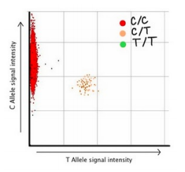

```python
Image(filename='bio011.jpg')
```

## #6

In the following ancestry composition graph, is this individual male or female?

###### A. Male

###### B. Female

###### C. Can’t be determined

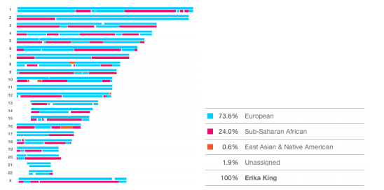

```python
Image(filename='bio012.jpg')
```

## B

## #7

This individual has a rich genetic history, sharing significant ancestry with individuals from both Europe and subSaharan Africa. Which are the only chromosomes that trace only with a European ancestry? Select any and all that apply.

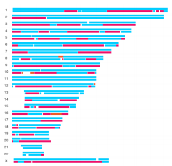

```python
Image(filename='bio013.jpg')
```

## 11, 21

## #8

Francisco has the following pedigree for him and his family:

Francisco is very interested in knowing about the deep past for the side of his family that is missing from the pedigree. Which of the following will give him the information that he’s looking for?

##### A. Y chromosome analysis

##### B. Mitochondrial chromosome analysis

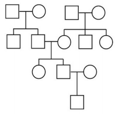

```python
Image(filename='bio014.jpg')
```

## B

## #9

True or False. An individual with majority genetic ancestry from subSaharan Africa would be expected to share more neanderthal SNVs than an individual with majority genetic ancestry from Europe. Why?

#### False, an individual with majority genetic ancestry from Europe has more neanderthal SNVs

## #10

After getting your personal genetic information back from 23andMe you log on and discover that you likely cannot taste certain bitter flavors like those found in Brussels Sprouts because you are homozygous for an allele in the TAS2R38 gene that codes for a taste receptor with altered function. If you were heterozygous for this allele then you would be able to taste these bitter flavors. Therefore, the Callele that prevents you from tasting bitter flavors is most likely:

##### A. Dominant

##### B. Recessive

##### Why?

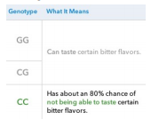

```python
Image(filename='bio015.jpg')
```

### B, With only CC combination a person cannot taste certain bitter flavors

## #11

Whether or not you have wet or dry earwax can be affected by what allele of the ABCC11 gene you have. The protein encoded by the ABCC11 gene transports fatlike compounds out of the cell; presumably this would be important in secreting some of the oily substances that make earwax wet. If the C allele codes for a very active ABCC11 gene and the T allele codes for a less active or inactive ABCC11 gene, based on the phenotypes associated with the phenotypes, which allele do you think is dominant? Why?

##### A. C-allele

##### B. T-allele

### A, only one C allele in combination is enough

## #12

A granddaughtergrandmother duo had their DNA genotyped and compared to see what portions of chromosomes were passed from the grandmother to the granddaughter. An analysis looking at the locations of a set of fertility genes showed the results visible here. How many alleles for fertility genes did the grandmother actually pass down to her granddaughter?

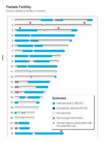

```python
Image(filename='bio016.jpg')
```

## 2

## #13

After submitting a DNA sample for personal genetics analysis, an individual logs in to find his/her ancestry results and is particularly interested in their paternal line. But the results say that the Paternal Haplotype (line) is "Unknown." Select any and all of the following reasons that, when taken together, explain why this information might be missing.

##### A. This person is male.

##### B. This person has no other paternal relatives in the 23andMe database.

##### C. This person does not have mitochondria.

##### D. This person does not have a Y chromosome.

##### E. This person is female

## B,D,E

## #14

How worried (worried about contaminated results) should 23andMe be if a saliva sample is submitted that contains a large amount of the following?

##### A. Bacteria (Worried or Not Worried)

##### B. White blood cells (Worried or Not worried)

##### C. Food particles (Worried or Not worried)

##### D. Another person's saliva (Worried or Not worried)

##### E. Viral DNA from a common cold (Worried or Not Worried)

## Worried: D

## #15

As knowledge about the genome grows, researchers are continually discovering new mutations/variations associated with important phenotypic traits that may not already be included on the current 23andMe genotyping platform (DNA chip). Based on what you learned about mutations in lesson 6 and the chip technology described in this lesson, which of the following are examples of variations that 23andMe could possibly include on their next chip? Select any and all that apply.

##### A. A SNV that shows a T-allele associated with a specific type of colon cancer

##### B. A single base deletion on chromosome 6 associated with a rare skin condition

##### C. A trinucleotide repeat expansion associated with Huntington’s Disease

##### D. An extra copy of chromosome 18 associated with Edwards syndrome

## A,B

## #16

23andMe gives customers the option of allowing their anonymized data to be used in research projects carried out by 23andMe researchers. So far, they have gained new insights into the genetics of Parkinson's disease, motion sickness, eye color, hair curl, and more. If you were a 23andMe customer, would you give consent for your data to be used in research initiatives like these? Why or why not?

## Of course, I would. More data units gives more information for research and more correct results.

## #17

In a 23andMe report for a complex trait like coronary heart disease, several SNVs are used to determine overall risk compared to the average person. Here in this analysis, how many SNVs would you say went into the risk assessment? Write your answer as a number.

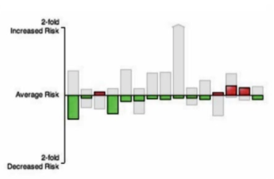

```python
Image(filename='bio017.jpg')
```

## 15

## #18

In this same risk assessment, if the overall risk is simply measured by averaging the risk of these individual SNVs, which of the following best characterizes this person’s risk for coronary heart disease compared to the average person? Why?

##### A. 100% probability the person will get coronary heart disease

##### B. Higher risk than the average person

##### C. Exactly the same risk as the average person

##### D. Lower risk than the average person

##### E. No risk at all

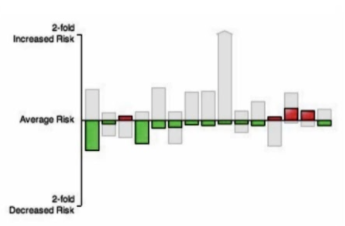

```python
Image(filename='bio017.jpg')
```

## D, most of the SNVs are in the Decreased Risk area

## #19

After unlocking the results an individual finds out they’re relative risk of developing chronic kidney disease is twice as much as the average person. The same is true for their risk of Alzheimer’s. However, which individual risk combination should you be more concerned about for developing the trait based on risk?

##### Your Risk Avg. Risk Relative Risk

##### A. Chronic Kidney Disease 6.7% 3.4% ~2x

##### B. Alzheimer’s 14% 7.2% ~2x

## B

## #20

Select the underlined word in the following paragraph that is incorrect. Then write the correct word that should replace it.

### At 23andMe, with consent, DNA can be extracted, prepared, and analyzed for about 1 million SNVs. Individual SNVs are identified by their rsID (IBD-wrong word), and individually or collectively they can give information about ancestry (including autosomal, mitochondrial, and Y-chromosome lineages) and traits (simple or complex).

## Lesson 8

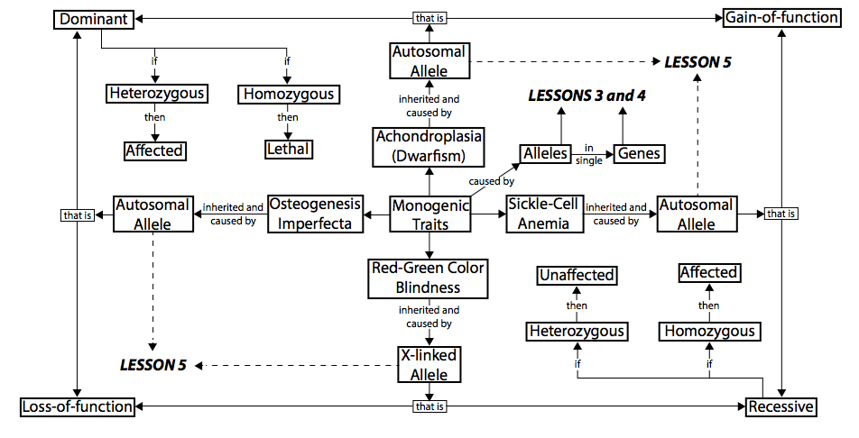

```python
Image(filename='cm08.jpg')
```

### Concept map

http://content.udacity-data.com/course/bio110/Lesson_8_Concept_Map.pdf

##### Monogenes/Monogenic Inheritance:

1 They produce discontinuous variations in the expression of traits.

2 A single dominant allele expresses the complete trait.

3 Monogenic inheritance controls qualitative traits.

4 A character is represented in an individual by a pair of alleles.

5 F1 individuals are similar to dominant parent.

6 F2 individuals resemble both the parents in the ratio of 3: 1.

7 No intermediates are produced in monogenic or qualitative inheritance.

8 There is no cumulative action in the presence of two dominant genes.

9 Individuals with dominant phenotype are more numerous than with recessive phenotype.

##### Polygenes/Polygenic Inheritance:

1 Polygenes produce continuous variations in the expression of traits.

2 A single dominant allele expresses only a unit of the trait.

3 Polygenic inheritance controls quantitative or metric trait.

4 A character is represented by one to several pairs of alleles.

5 F1, individuals are intermediate between the two parents.

6 Depending upon the number of polygenes, 2/4 (one pair), 2/16 (two pairs) or 2/64 (three pairs) F: individuals resemble the parental types.

7 Intermediates are quite common in polygenic or quantitative inheritance.

8 The dominant genes have cumulative effect on the expression of the trait.

9 Individuals with dominant trait are usually as few as with recessive trait. Intermediate forms are more numerous.

http://learn.genetics.utah.edu/content/inheritance/activities/pdfs/Inherited%20Human%20Traits%20Quick%20Reference_Public.pdf

What kinds of gene mutations are possible? The DNA sequence of a gene can be altered in a number of ways. Gene mutations have varying effects on health, depending on where they occur and whether they alter the function of essential proteins. The types of mutations include:

Missense mutation This type of mutation is a change in one DNA base pair that results in the substitution of one amino acid for another in the protein made by a gene.

Nonsense mutation A nonsense mutation is also a change in one DNA base pair. Instead of substituting one amino acid for another, however, the altered DNA sequence prematurely signals the cell to stop building a protein. This type of mutation results in a shortened protein that may function improperly or not at all.

Insertion An insertion changes the number of DNA bases in a gene by adding a piece of DNA. As a result, the protein made by the gene may not function properly.

Deletion A deletion changes the number of DNA bases by removing a piece of DNA. Small deletions may remove one or a few base pairs within a gene, while larger deletions can remove an entire gene or several neighboring genes. The deleted DNA may alter the function of the resulting protein(s).

Duplication A duplication consists of a piece of DNA that is abnormally copied one or more times. This type of mutation may alter the function of the resulting protein.

Frameshift mutation This type of mutation occurs when the addition or loss of DNA bases changes a gene's reading frame. A reading frame consists of groups of 3 bases that each code for one amino acid. A frameshift mutation shifts the grouping of these bases and changes the code for amino acids. The resulting protein is usually nonfunctional. Insertions, deletions, and duplications can all be frameshift mutations.

Repeat expansion Nucleotide repeats are short DNA sequences that are repeated a number of times in a row. For example, a trinucleotide repeat is made up of 3-base-pair sequences, and a tetranucleotide repeat is made up of 4-base-pair sequences. A repeat expansion is a mutation that increases the number of times that the short DNA sequence is repeated. This type of mutation can cause the resulting protein to function improperly.

#### 4 Different types of dominant mutations

Why do some mutations act in a dominant fashion? Below we examine some different mechanisms through which a mutation can confer a dominant phenotype. In certain situations, different dominant alleles may require different mapping strategies. These situations must be managed on a case-by-case basis. In each example below, we will consider the fictional dom-1 gene and imagine different situations that could give rise to various types of dominant alleles in dom-1.

4.1. Haploinsufficiency

This describes a situation in which one copy (haplo) of a wild-type gene is not enough to provide wild-type function when the other copy is compromised. This can only occur for loss-of-function alleles. Consider again our fictional dominant mutation, dom-1. Let's assume that a certain threshold of dom-1 activity is required to avoid the abnormal spiked-head phenotype; two copies of the wild-type gene are required to achieve that threshold, and any drop below that threshold allows the mutant spiked head to form. Mutations in dom-1 that reduce or eliminate its activity would therefore behave dominantly because in heterozygous animals, the single remaining wild-type copy of the dom-1 gene would be insufficient to provide the wild-type levels of gene activity. Thus, the loss-of-function dom-1 mutant allele may produce a similar phenotype whether present in one or two copies and behaves in a dominant fashion. Alternatively, dom-1/+ heterozygous animals may display a phenotype that is quantitatively or qualitatively different from homozygous dom-1/dom-1 animals, since the former would still retain half the normal gene dose.

4.2. Dominant-negative alleles

These typically occur when the mutant allele does not function normally and either directly inhibits the activity of the wild-type protein (usually through dimerization) or inhibits the activity of another protein that is required for the normal function of the wild-type protein (such as an activator or downstream component in a pathway). Although this situation can effectively result in the loss of function of the wild-type protein, it differs markedly from haploinsufficiency. Consider an animal that is heterozygous for a dominant-negative allele of dom-1. In this case, we'll also imagine that the single wild-type copy of dom-1 would normally provide enough dom-1 activity to avoid the spiked-head phenotype. However, because of a dominant-negative version of dom-1 would actually interfere with the function of wild-type dom-1 its activity is further reduced and a mutant phenotype results.

A well-known example of a gene that can incur dominant-negative mutations is the small GTPase Ras. These dominant-negative alleles of Ras are not functional themselves because they preferentially bind GDP and stay locked in the inactive state. In addition, they also prevent the Ras exchange factor (which binds Ras-GDP and catalyzes GDP/GTP exchange and subsequent Ras activation) from acting on wild-type Ras, essentially killing all Ras activity.

4.3. Dominant gain-of-function (GOF) alleles

Also termed hypermorphs, these refer to mutations that result in elevated levels of gene activity. In some cases, dominant GOF mutations may acquire novel biochemical activities, in which case they may be referred to as neomorphs. It is possible to imagine numerous scenarios that might lead to the removal of normal regulatory constraints and the enhancement of protein activity. For example, a mutation in the promoter region could lead to overexpression of the gene and the saturation of negative regulatory pathways. Alternatively, point mutations in a region of a gene important for its regulation could lead to inappropriate activity and mutant phenotypes. Let's revisit dom-1 and imagine it is an enzyme whose activity promotes head development. Assume that normal levels of dom-1 activity result in normal head development and any dom-1 activity above normal levels results in a spiked head. Also assume that a negative regulatory phosphate group is added to an N-terminal serine when dom-1 activity gets to the threshold required for normal development. A point mutation that makes this serine phosphorylation impossible (e.g., Ser → Ala) could remove the negative regulation of dom-1 and allow its activity to proceed unchecked, thus leading to the spiked-head phenotype. In short, too much of a good thing can lead to developmental abnormalities.

4.4. Semi-dominant alleles

It is actually quite typical for dominant alleles to behave in a partially dominant fashion. Alleles are designated semi-dominant when the penetrance of the phenotype in heterozygous animals (dom-1/+) is less than that observed for homozygous animals (dom-1/dom-1). For dom-1, this would be the case if dom-1/dom-1 animals were 100% spiked head and dom-1/+ animals were 60% spiked head. This is an important point, as the basic mapping strategies outlined above were assuming 100% dominance. In practice, this is not necessarily that difficult to deal with, as the presence of the mutation will always be seen by the next generation, as is the case for any recessive allele. Thus mapping a semi-dominant mutation will simply require following progeny for an extra generation to distinguish between dom-1/+ and +/+ animals.

##### A heterozygote advantage (heterozygous advantage)

describes the case in which the heterozygote genotype has a higher relative fitness than either the homozygote dominant or homozygote recessive genotype. The specific case of heterozygote advantage due to a single locus is known as overdominance. In more general terms, overdominance is a condition in genetics where the phenotype of the heterozygote lies outside of the phenotypical range of both homozygote parents, and heterozygous individuals have a higher fitness than homozygous individuals.

Polymorphism can be maintained by selection favoring the heterozygote, and this mechanism is used to explain the occurrence of some kinds of genetic variability. A common example is the case where the heterozygote conveys both advantages and disadvantages, while both homozygotes convey a disadvantage. A well-established case of heterozygote advantage is that of the gene involved in sickle cell anaemia.

#### Single-gene

A single-gene disorder is the result of a single mutated gene. Over 4000 human diseases are caused by single-gene defects. Single-gene disorders can be passed on to subsequent generations in several ways. Genomic imprinting and uniparental disomy, however, may affect inheritance patterns. The divisions between recessive and dominant types are not "hard and fast", although the divisions between autosomal and X-linked types are (since the latter types are distinguished purely based on the chromosomal location of the gene). For example, achondroplasia is typically considered a dominant disorder, but children with two genes for achondroplasia have a severe skeletal disorder of which achondroplasics could be viewed as carriers. Sickle-cell anemia is also considered a recessive condition, but heterozygous carriers have increased resistance to malaria in early childhood, which could be described as a related dominant condition. When a couple where one partner or both are sufferers or carriers of a single-gene disorder wish to have a child, they can do so through in vitro fertilization, which means they can then have a preimplantation genetic diagnosis to check whether the embryo has the genetic disorder.

Autosomal dominant

Only one mutated copy of the gene will be necessary for a person to be affected by an autosomal dominant disorder. Each affected person usually has one affected parent. The chance a child will inherit the mutated gene is 50%. Autosomal dominant conditions sometimes have reduced penetrance, which means although only one mutated copy is needed, not all individuals who inherit that mutation go on to develop the disease. Examples of this type of disorder are Huntington's disease, neurofibromatosis type 1, neurofibromatosis type 2, Marfan syndrome, hereditary nonpolyposis colorectal cancer, hereditary multiple exostoses (a highly penetrant autosomal dominant disorder), Tuberous sclerosis, Von Willebrand disease, and acute intermittent porphyria. Birth defects are also called congenital anomalies.

Autosomal recessive

Two copies of the gene must be mutated for a person to be affected by an autosomal recessive disorder. An affected person usually has unaffected parents who each carry a single copy of the mutated gene (and are referred to as carriers). Two unaffected people who each carry one copy of the mutated gene have a 25% risk with each pregnancy of having a child affected by the disorder. Examples of this type of disorder are Albinism, Medium-chain acyl-CoA dehydrogenase deficiency, cystic fibrosis, sickle-cell disease, Tay-Sachs disease, Niemann-Pick disease, spinal muscular atrophy, and Roberts syndrome. Certain other phenotypes, such as wet versus dry earwax, are also determined in an autosomal recessive fashion.

X-linked dominant

X-linked dominant disorders are caused by mutations in genes on the X chromosome. Only a few disorders have this inheritance pattern, with a prime example being X-linked hypophosphatemic rickets. Males and females are both affected in these disorders, with males typically being more severely affected than females. Some X-linked dominant conditions, such as Rett syndrome, incontinentia pigmenti type 2, and Aicardi syndrome, are usually fatal in males either in utero or shortly after birth, and are therefore predominantly seen in females. Exceptions to this finding are extremely rare cases in which boys with Klinefelter syndrome (47,XXY) also inherit an X-linked dominant condition and exhibit symptoms more similar to those of a female in terms of disease severity. The chance of passing on an X-linked dominant disorder differs between men and women. The sons of a man with an X-linked dominant disorder will all be unaffected (since they receive their father's Y chromosome), and his daughters will all inherit the condition. A woman with an X-linked dominant disorder has a 50% chance of having an affected fetus with each pregnancy, although it should be noted that in cases such as incontinentia pigmenti, only female offspring are generally viable. In addition, although these conditions do not alter fertility per se, individuals with Rett syndrome or Aicardi syndrome rarely reproduce.

X-linked recessive

X-linked recessive conditions are also caused by mutations in genes on the X chromosome. Males are more frequently affected than females, and the chance of passing on the disorder differs between men and women. The sons of a man with an X-linked recessive disorder will not be affected, and his daughters will carry one copy of the mutated gene. A woman who is a carrier of an X-linked recessive disorder (XRXr) has a 50% chance of having sons who are affected and a 50% chance of having daughters who carry one copy of the mutated gene and are therefore carriers. X-linked recessive conditions include the serious diseases hemophilia A, Duchenne muscular dystrophy, and Lesch-Nyhan syndrome, as well as common and less serious conditions such as male pattern baldness and red-green color blindness. X-linked recessive conditions can sometimes manifest in females due to skewed X-inactivation or monosomy X (Turner syndrome).

Y-linked Main article: Y linkage Y-linked disorders, also called holandric disorders, are caused by mutations on the Y chromosome. These conditions display may only be transmitted from the heterogametic sex (e.g. male humans) to offspring of the same sex. More simply, this means that Y-linked disorders in humans can only be passed from men to their sons; females can never be affected because they do not possess Y-allosomes.

Y-linked disorders are exceedingly rare but the most well-known examples typically cause infertility. Reproduction in such conditions is only possible through the circumvention of infertility by medical intervention.

Mitochondrial

This type of inheritance, also known as maternal inheritance, applies to genes in mitochondrial DNA. Because only egg cells contribute mitochondria to the developing embryo, only mothers can pass on mitochondrial conditions to their children. An example of this type of disorder is Leber's hereditary optic neuropathy.

#### Nonsense-mediated mRNA decay (NMD)

is a surveillance pathway that exists in all eukaryotes. Its main function is to reduce errors in gene expression by eliminating mRNA transcripts that contain premature stop codons. Translation of these aberrant mRNAs could, in some cases, lead to deleterious gain-of-function or dominant-negative activity of the resulting proteins.

The phenomenon of NMD was first described in human cells and in yeast almost simultaneously in 1979. This suggested broad phylogenetic conservation and an important biological role of this intriguing mechanism. NMD was discovered when it was realized that cells often contain unexpectedly low concentrations of mRNAs that are transcribed from alleles carrying nonsense mutations. Nonsense mutations code for a stop codon. Converting an amino acid into a premature stop codon causes the protein to be shortened. How much of the protein is lost determines whether or not the protein is still functional. Nonsense-mediated decay is a new and important aspect to human genetics. It has the possibility to not only limit the translation of abnormal proteins, but it can occasionally cause detrimental effects in specific genetic mutations.

```python
from IPython.core.display import HTML
HTML('<a title="By Danmen (Miles F. Wilkinson & Ann-Bin Shyu) \
     [CC BY-SA 3.0 (http://creativecommons.org/licenses/by-sa/3.0) or GFDL (http://www.gnu.org/copyleft/fdl.html)], \
     via Wikimedia Commons" href="https://commons.wikimedia.org/wiki/File%3ANMD_pathway.jpg"><img width="512" \
     alt="NMD pathway" src="https://upload.wikimedia.org/wikipedia/commons/thumb/0/08/NMD_pathway.jpg/512px-NMD_pathway.jpg"/></a>')
```

[figure not shown]

## Problem set 8

http://content.udacity-data.com/course/bio110/Lesson_8_Problem_Set.pdf

## #1

Although a mutation that causes a premature stop codon will shorten the overall length of a protein, a cell has a way of recognizing when premature stop codons exist in some mRNA transcripts and clearing them from the cell in a process called Nonsense Mediated Decay, or NMD. Considering only the effects of NMD, would you expect a nonsense mutation that results in the NMD pathway to be a:

##### A. Loss-of-function allele

##### B. Gain-of-function allele

Why?

### A, NMD should destroy poorly produced gene product with premature stop codons

## #2

Without knowing anything about the actual disease that is traced in this partial pedigree, does this disease show an inheritance pattern likely be autosomal, sexlinked, or maternal/mitochondrial, and how do you know?

#### A. Autosomal

#### B. Sex-linked

#### C. Maternal/Mitochondrial

Why?

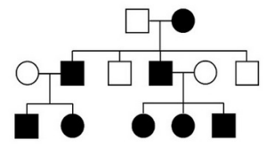

```python
Image(filename='bio018.jpg')
```

### A: both sex were affected, males can pass the trait too

## #3

Does this disease appear to be dominant or recessive? Why?

##### A. Dominant

##### B. Recessive

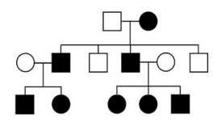

```python
Image(filename='bio019.jpg')
```

### A: no skipped generations

## #4

The pedigree shown is from an American family afflicted with Huntington's Disease. It is caused by an expanded trinucleotide repeat (CAG) encoding glutamine in the gene encoding huntingtin, HTT, on chromosome 4. The typical number of CAG repeats in an unaffected person is 18-19, and the average number in Huntington's patients is about 47. Which mutation best describes this trinucleotide repeat expansion?

##### A. Silent mutation

##### B. Missense mutation

##### C. Nonsense mutation

##### D. Frameshift mutation

##### E. Insertion mutation

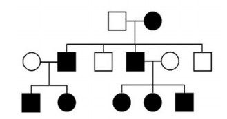

```python
Image(filename='bio020.jpg')
```

## E

## #5

Huntington's Disease (HD) is a lethal condition that is inherited in a dominant fashion, i.e. only one copy of the mutated allele is required for the onset of disease. The average age of onset can be quite varied, but typically it is between the ages of 30 and 50. Which of the following two statements must be true? Select any and all that apply.

##### A. All carriers of the HD mutation ultimately die of the disease

##### B. The HD mutation persists in the gene pool because reproduction can happen before the onset of symptoms

##### C. Natural selection prevents the HD mutation from spreading

## A,B

## #6

There is currently no cure for Huntington's Disease. If you knew that the disease was prevalent in your extended family, would you want to be screened for the disease causing mutation? Why or why not?

### I think the nature gives us the best chance by choosing randomly. This case is a big question. Maybe I want to be screened as a usual human but it can be a mutation which carries some hidden genetic data (for example, about resistance to something else).

## #7

After receiving your personal genetics results you become particularly interested in a genetic disorder that your grandmother had: Autosomal Recessive Polycystic Kidney Disease. Knowing just the name alone, how many copies of a mutation would be needed to cause the disease?

## 2

## #8

If two parents each carry one copy of a mutation in the PKHD1 gene that causes Autosomal Recessive Polycystic Kidney Disease, what is the probability that a child of theirs would: be affected? be a carrier? be unaffected? be unaffected and not a carrier?

##### Affected A carrier Unaffected Unaffected (but not a carrier)

##### A. 100% 100% 100% 100%

##### B. 75% 75% 75% 75%

##### C. 50% 50% 50% 50%

##### D. 25% 25% 25% 25%

##### E. 0% 0% 0% 0%

### Affected - 25%, A carrier - 50%, Unaffected - 75%, Unaffected (but not a carrier)- 25%

## #9

A dominant negative mutation indicates a mutant gene product that adversely affects the normal gene product within the same cell, usually by combining with it. Although the dominant negative has lost a certain part of its function (loss-of-function), it out-competes the normal protein, making the mutant effects dominant. This is true for the collagen (COL1A1) mutation in osteogenesis imperfecta. Based on this, which do you think would have a more detrimental effect? Why?

##### A. One copy of a silent collagen (COL1A1) mutation

##### B. One copy of a dominant negative collagen (COL1A1) mutation

##### C. One copy of a complete collagen (COL1A1) deletion mutation

### B, it will affect the normal protein

## #10

Observe the following pedigree for the inheritance of a particular trait: Is the this an example of a dominant or recessive trait? Is it autosomal, sex-linked, or maternal inheritance pattern? Why?

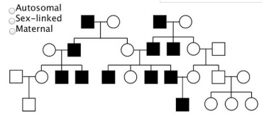

```python
Image(filename='bio021.jpg')
```

## sex-linked (only men affected); dominant (no skipped generations)

## #11

This pedigree is an example of a Y-linked gene. Which of the following statements must be true? Select any and all that apply.

##### A. Affected fathers always produce affected sons

##### B. Unaffected sons always have unaffected fathers

##### C. Affected individuals are homozygous

##### D. Affected fathers have a 25% probability of having an affected child

##### E. Daughters can be affected if they are homozygous

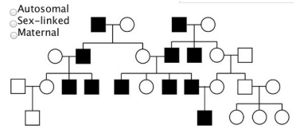

```python
Image(filename='bio021.jpg')
```

## A,B

## #12

Match the trait number with the given category of trait:

#### 1. Red-Green Color Blindness ___ dominant and loss-of-function

#### 2. Osteogenesis Imperfecta ___ dominant and gain-of-function

#### 3. Achondroplasia ___ recessive and loss-of-function

#### 4. Sickle Cell Anemia ___ recessive and gain-of-function

## 2,3,1,4

## #13

#### Dominant or Recessive

#### Autosomal or Sex-linked or Maternal

```python
Image(filename='bio022.jpg')
```

[output not shown]

## autosomal (male and female can pass); dominant (no skipped generations)

## #14

For this pedigree of fatal familial insomnia, which of the following must be true? Select any and all that apply.

##### A. This is an example of heterozygote advantage

##### B. There is not strong selection against this trait because the onset of symptoms are typically after reproductive age

##### C. The heterozygous condition is lethal

##### D. The homozygous recessive condition is lethal

```python
Image(filename='bio022.jpg')
```

[output not shown]

## B,C

## #15

True or False.

In the case of fatal familial insomnia, a heterozygous affected individual who mates with an unaffected individual has a 50% chance of having an unaffected child. Why?

```python
Image(filename='bio022.jpg')
```

[output not shown]

## True, (variants for children: +/-, +/-, -/-, -/-)

## #16

True or False. A heterozygous affected individual who mate with another heterozygous person has a 50% chance of having an affected child. Why?

```python
Image(filename='bio022.jpg')
```

[output not shown]

## False, (variants for children: +/+, +/-, -/+, -/-)

## #17

##### Fill in the blank to make the statement true.

An affected *__* with one copy of an autosomal *__* allele has a bigger chance of having an affected offspring than an affected *__* with one copy of an X-linked *__* allele if both individuals mate with an unaffected partner.

##### [Word bank: dominant, recessive, male, female]

## female, dominant, male, recessive

## #18

Select the underlined word in the following paragraph that is incorrect. Then write the correct word that should replace it.

The recessive sickle cell allele has not been eliminated from the gene pool because it exhibits a homozygote advantage with the dominant allele in areas with a high prevalence of Malaria.

### wrong - homozygote, right - heterozygote

## #19

Which of the following statements is true? Select any and all that apply. (think hard about this one!) Why?

##### A. Silent mutations always result in loss-of-function alleles

##### B. Missense mutations always result in loss-of-function alleles

##### C. Nonsense mutations always result in loss-of-function alleles

##### D. Frameshift mutations always result in loss-of-function alleles

### NONE, they can result in gain-of-function alleles

## #20

Two of the following three statements are true. Identify the false statement and explain why.

##### A. Monogenic traits are caused by variations in single genes.

##### B. A dominant allele can also be recessive depending on the trait perspective.

##### C. Loss-of-function mutations are always recessive.

### C, loss-of-function mutations can be dominant (Osteogenesis Imperfecta)